# Prediction Assignment

Filipe Drumond Reis

1 de maio de 2017

```r
knitr::opts_chunk$set(echo = TRUE, warning=FALSE, comment=FALSE, message=FALSE)
```

## Introduction

One thing that people regularly do is quantify how much of a particular activity they do, but they rarely quantify how well they do it. In this project, the goal will be to use data from accelerometers on the belt, forearm, arm, and dumbell of 6 participants.

The data used in this project are from the Groupware @ LES research group related to the HAR - Human Activity Recognition project.

Groupware @ LES http://groupware.les.inf.puc-rio.br/ HAR http://groupware.les.inf.puc-rio.br/harlingweight_lifting_exercises

We used the Weight Lifting Exercises Dataset which presents data about “six young health participants were asked to perform one set of 10 repetitions of the Unilateral Dumbbell Biceps Curl in five different fashions: exactly according to the specification (Class A), throwing the elbows to The front (Class B), lifting the dumbbell only halfway (Class C), lowering the dumbbell only halfway (Class D) and throwing the hips to the front (Class E).

Class A corresponds to the specified execution of the exercise, while the other 4 classes correspond to common mistakes. Participants were supervised by an experienced weight lifter to make sure the execution complied with the manner they were supposed to simulate. " # The goal of the project is to predict the manner in which they did the exercise.

## 1 - Data

The following Libraries were used:

```r
library(caret)
library(randomForest)
library(corrplot)
library(rpart)
library(rpart.plot)
library(rattle)
```

The seed set was 12345

```r
set.seed(12345)
```

# 1.1 Getting the data

We used the Weight Lifting Exercises Dataset.

The training data: https://d396qusza40orc.cloudfront.net/predmachlearn/pml-training.csv

The test data: https://d396qusza40orc.cloudfront.net/predmachlearn/pml-testing.csv

```r
training <- read.csv(url("https://d396qusza40orc.cloudfront.net/predmachlearn/pml-training.csv"), na.strings=c("NA","#DIV/0!",""))
test <- read.csv(url("https://d396qusza40orc.cloudfront.net/predmachlearn/pml-testing.csv"), na.strings=c("NA","#DIV/0!",""))
```

Partioning Training data set into two data sets, 75% for training1, 25% for testing1

```r
inTrain <- createDataPartition(y=training$classe, p=0.75, list=FALSE)
training1 <- training[inTrain, ]
testing1 <- training[-inTrain, ]
dim(training1)
```

```
FALSE [1] 14718   160
```

```r
dim(testing1)
```

```
FALSE [1] 4904  160
```

# 1.2 Cleaning the data

All variables with near zero variance predictors were identified and removed.

```r
NZV <- nearZeroVar(training1)
training1 <- training1[, -NZV]
testing1  <- testing1[, -NZV]
dim(training1)
```

```
FALSE [1] 14718   129
```

```r
dim(testing1)
```

```
FALSE [1] 4904  129
```

The first to the fifth column were removed, since they were identification variables. So as not to interfere with the forecasting models.

```r
training1 <- training1[,-(1:5)]
testing1  <- testing1 [,-(1:5)]
```

The variables that had 50% of the cases were removed.

```r
halfNAs<- sapply(training1, function(x) mean(is.na(x))) > 0.5
training1 <- training1[, halfNAs==FALSE]
testing1 <- testing1[, halfNAs==FALSE]
dim(training1)
```

```
FALSE [1] 14718    54
```

```r
dim(testing1)
```

```
FALSE [1] 4904   54
```

## 2 - Prediction Models

Two methods of prediction were trained and tested and the method with the best accuracy was used to respond to the quiz.

The two methods were: Random Forests and Decision Tree

## 3 - Training and test Models

# 3.1 Prediciton Model Random Forests

To train:

```r
fitRF <- randomForest(classe ~. , data=training1)
```

To test using confusion Matrix:

```r
predictRF <- predict(fitRF, testing1, type = "class")
confusionMatrix(predictRF, testing1$classe)
```

```
FALSE Confusion Matrix and Statistics
FALSE
FALSE           Reference
FALSE Prediction    A    B    C    D    E
FALSE          A 1395    4    0    0    0
FALSE          B    0  943    2    0    0
FALSE          C    0    2  852    4    0
FALSE          D    0    0    1  800    4
FALSE          E    0    0    0    0  897
FALSE
FALSE Overall Statistics
FALSE
FALSE                Accuracy : 0.9965
FALSE                  95% CI : (0.9945, 0.998)
FALSE     No Information Rate : 0.2845
FALSE     P-Value [Acc > NIR] : < 2.2e-16
FALSE
FALSE                   Kappa : 0.9956
FALSE  Mcnemar's Test P-Value : NA
FALSE
FALSE Statistics by Class:
FALSE
FALSE                      Class: A Class: B Class: C Class: D Class: E
FALSE Sensitivity            1.0000   0.9937   0.9965   0.9950   0.9956
FALSE Specificity            0.9989   0.9995   0.9985   0.9988   1.0000
FALSE Pos Pred Value         0.9971   0.9979   0.9930   0.9938   1.0000
FALSE Neg Pred Value         1.0000   0.9985   0.9993   0.9990   0.9990
FALSE Prevalence             0.2845   0.1935   0.1743   0.1639   0.1837
FALSE Detection Rate         0.2845   0.1923   0.1737   0.1631   0.1829
FALSE Detection Prevalence   0.2853   0.1927   0.1750   0.1642   0.1829
FALSE Balanced Accuracy      0.9994   0.9966   0.9975   0.9969   0.9978
```

# 3.2 Prediciton Model Decision Tree

To train:

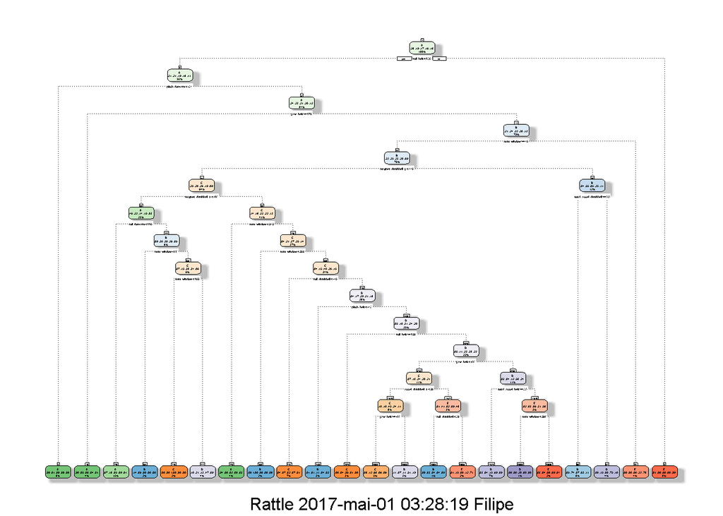

```r
fitDT <- rpart(classe ~ ., data=training1, method="class")
fancyRpartPlot(fitDT)
```

To test using confusion Matrix:

```r
predictDT <- predict(fitDT, testing1, type = "class")
confusionMatrix(predictDT,testing1$classe)
```

```
FALSE Confusion Matrix and Statistics
FALSE
FALSE           Reference
FALSE Prediction    A    B    C    D    E
FALSE          A 1275  150   32   72   21
FALSE          B   31  631   39   14   69
FALSE          C   37   64  674   38   12
FALSE          D   45   89  110  620  110
FALSE          E    7   15    0   60  689
FALSE
FALSE Overall Statistics
FALSE
FALSE                Accuracy : 0.793
FALSE                  95% CI : (0.7814, 0.8043)
FALSE     No Information Rate : 0.2845
FALSE     P-Value [Acc > NIR] : < 2.2e-16
FALSE
FALSE                   Kappa : 0.7375
FALSE  Mcnemar's Test P-Value : < 2.2e-16
FALSE
FALSE Statistics by Class:
FALSE
FALSE                      Class: A Class: B Class: C Class: D Class: E
FALSE Sensitivity            0.9140   0.6649   0.7883   0.7711   0.7647
FALSE Specificity            0.9216   0.9613   0.9627   0.9137   0.9795
FALSE Pos Pred Value         0.8226   0.8048   0.8170   0.6366   0.8936
FALSE Neg Pred Value         0.9642   0.9228   0.9556   0.9532   0.9487
FALSE Prevalence             0.2845   0.1935   0.1743   0.1639   0.1837
FALSE Detection Rate         0.2600   0.1287   0.1374   0.1264   0.1405
FALSE Detection Prevalence   0.3161   0.1599   0.1682   0.1986   0.1572
FALSE Balanced Accuracy      0.9178   0.8131   0.8755   0.8424   0.8721
```

## 4 - Results

In that case, the Random Forest model was applied in testing data set.

```r
predicttest <- predict(fitRF, newdata=test)
predicttest
```

```
FALSE  1  2  3  4  5  6  7  8  9 10 11 12 13 14 15 16 17 18 19 20
FALSE  B  A  B  A  A  E  D  B  A  A  B  C  B  A  E  E  A  B  B  B
FALSE Levels: A B C D E
```